# Shiny Birdpop App Scratch

Author

Steven Mitchell

# Objectives & Pseudocode

- Plot exploring correlations between morphometric measurements. Y-axis will be weight. Categorical predictor variables can be selected from widget (age, flight feather wear, etc).
  - Wrangle data into form that will allow easy plotting
  - Set up inputs/outputs
  - Make a global ggplot theme
- Plot of counts of adult birds over time with filter-by-species widget and slider bar to select timeframe displayed
  - Wrangle data into yearly time series tsibble
  - Summarize counts by species
  - Set up species filter input/output
- Plot displaying species richness by site with filter function.
  - Wrangle data into form allowing easy plotting
  - Summarize by species counts per site per year
- Bonus: abundance estimates per species using mark-recapture functions in ‘recapr’

### Loadpackages

```r
library(tidyverse)
library(here)
library(tsibble)
  library(janitor)
```

### load data

```r
maps_banding <- read_csv(here('data','MAPS_BANDING_capture_data.csv')) %>%
  clean_names()
```

## Widget 1:

```r
morphometrics <- maps_banding %>%
  select(spec, age, sex, f, fw, wng, weight, brstat) %>%
  filter(weight != 0, wng != 0, age != 0, brstat != '?') %>%
  mutate(age = ifelse(age == 4, "Nestling",
               ifelse(age == 2, "1st year",
               ifelse(age == 1, ">1st year",
               ifelse(age == 5, "2nd year",
               ifelse(age == 6, ">2nd year", NA)))))) %>%
  mutate(age = as.factor(age)) %>%
  mutate(brstat = ifelse(brstat == 'B', "Breeder",
                  ifelse(brstat == 'U', "Usual breeder",
                  ifelse(brstat == 'O', "Occasional breeder",
                  ifelse(brstat == 'T', "Transient",
                  ifelse(brstat == 'A', "Altitudinal disperser",
                  ifelse(brstat == 'M', 'Migrant', NA))))))) %>%
  mutate(brstat = as.factor(brstat)) %>%
  mutate(spec = as.factor(spec)) %>%
  mutate(f = as.factor(f)) %>%
  drop_na()

unique(morphometrics$spec)
```

```
  [1] SSHA MOUQ CAHU RUHU ALHU RBSA DOWO HAWO OSFL WEWP WIFL HAFL DUFL WEFL PSFL
 [16] CAVI HUVI WAVI STJA CASJ BCCH CBCH BUSH RBNU BRCR BEWR HOWR WIWR SWTH HETH
 [31] AMRO WREN CEDW OCWA NAWA YEWA AUWA BTYW HEWA MGWA COYE WIWA YBCH WETA SPTO
 [46] BRSP FOSP SOSP LISP PSWS GWCS ORJU BHGR LAZB BHCO PUFI PISI LEGO AMGO CAQU
 [61] VIRA MODO YBCU VASW ANHU RSFL NFIN BLPH ATFL YTVI TRES VGSW NRWS CLSW BARS
 [76] GCKI RCKI EUST NOPA MYWA YRWA BAWW NOWA CHSP BTSP SAVS WTSP NWCS WCSP GCSP
 [91] RBGR RWBL BRBL BUOR HOFI RECR HOSP NOPO TRFL BANS CSWA CALT CCSP CAJA GRCA
[106] AMRE OVEN WEBL RNSA MOCH VATH TOWA THWH CAFI EVGR WISA GRFL MWCS TOSO MAWR
[121] LEFL OATI ACWO GTTO BRTH PAWR MAWA DEJU SPSA LEWO WEKI WBNU ALFL WWCR NSWO
[136] WHWO BGGN RRSH WEWA REVI HOWA ATTW PIGR TEWA RUGR BTAH INBU BEKI BCHU AMDI
[151] AMKE NOMO VESP LASP GRSP WEME
166 Levels: ACWO ALFL ALHU AMDI AMGO AMKE AMRE AMRO ANHU ATFL ATTW AUWA ... YTVI
```

### Exploratory plots

```r
weight_x_wng_plot <- ggplot(morphometrics, aes(x = wng, y = weight, color = spec)) +
  geom_point() +
  theme_bw() +
  theme(legend.position = "none") +
  labs(x = 'Wing chord (length in mm)', y = 'Body weight (g)')

weight_x_age_plot <- ggplot(morphometrics, aes(x = age, y = weight)) +
  geom_boxplot() +
  scale_y_log10() +
  theme_bw() +
  theme(legend.position = "none") +
  labs(x = 'Age class', y = 'Body weight (log10 g)')

fat_x_weight_plot <- ggplot(morphometrics, aes(x = f, y = weight)) +
  geom_boxplot() +
  scale_y_log10() +
  theme_bw() +
  labs(x = 'Fat', y = 'Body weight (log10 g)')

sex_x_weight_plot <- ggplot(morphometrics, aes(x = sex, y = weight)) +
  geom_boxplot() +
  scale_y_log10() +
  theme_bw() +
  labs(x = 'Sex', y = 'Body weight (log10 g)')

bs_x_weight_plot <- ggplot(morphometrics, aes(x = brstat, y = weight)) +
  geom_boxplot() +
  scale_y_log10() +
  theme_bw() +
  labs(x = 'Breeding Status', y = 'Body weight (log10 g)')
```

- Plot of counts of adult birds over time with filter-by-species widget and slider bar to select timeframe displayed
  - Wrangle data into yearly time series tsibble
  - Summarize counts by species
  - Set up species filter input/output

```r
counts_ts <- maps_banding %>%
  select(spec, date, station) %>%
  drop_na() %>%
  group_by(spec, date) %>%
  count()
```

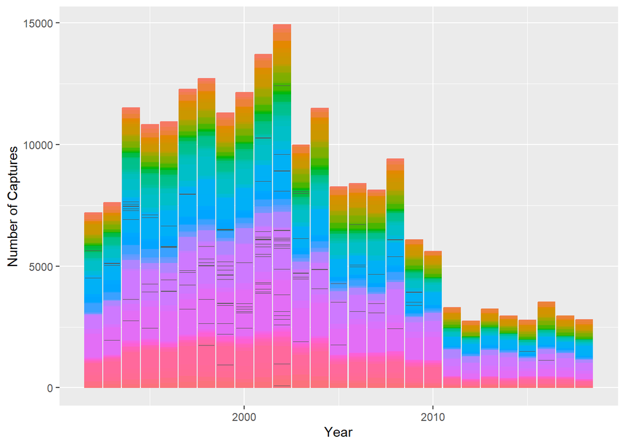

```r
ggplot(counts_ts, aes(x = year(date), y = n, color = spec)) +
  geom_col() +
  theme(legend.position = 'none')+
  labs(y = 'Number of Captures', x = 'Year')
```

- Plot displaying species richness by site with filter function.
  - Wrangle data into form allowing easy plotting
  - Summarize by species counts per site per year

```r
sr <- maps_banding %>%
  select(spec, date, station) %>%
  drop_na() %>%
  group_by(spec, station) %>%
  count()
```

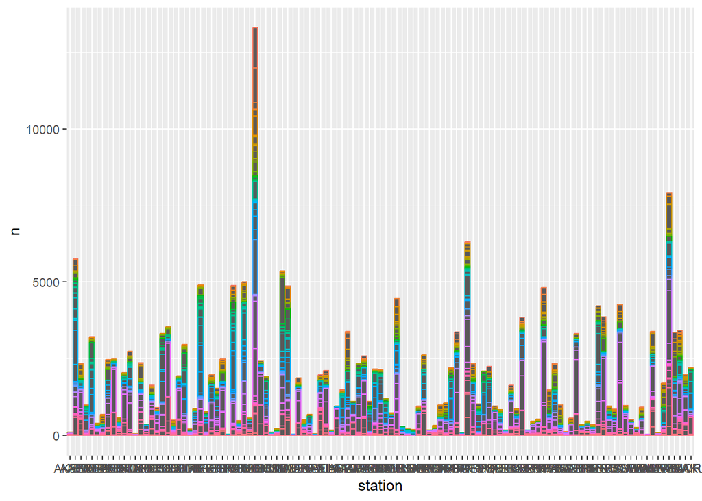

```r
ggplot(sr, aes(x = station, y = n, col = spec))+
  geom_col() +
  theme(legend.position = 'none')
```